# Course5-Assignment1

Vikram

10/1/2020

#** Physical Activity Monitoring Assignment** ## *Reproducible Research-Week2-Assignment*##

-To begin with INSTALL and LOAD the follwoing packages. (dplyr, ggplot2, lubridate, knitr, markdown).

```r
Data_assignment<-read.csv(file= "activity.csv", header = TRUE, sep=",")

str(Data_assignment)
```

```
## 'data.frame':    17568 obs. of  3 variables:
##  $ steps   : int  NA NA NA NA NA NA NA NA NA NA ...
##  $ date    : chr  "2012-10-01" "2012-10-01" "2012-10-01" "2012-10-01" ...
##  $ interval: int  0 5 10 15 20 25 30 35 40 45 ...
```

```r
head(Data_assignment)
```

```
##   steps       date interval
## 1    NA 2012-10-01        0
## 2    NA 2012-10-01        5
## 3    NA 2012-10-01       10
## 4    NA 2012-10-01       15
## 5    NA 2012-10-01       20
## 6    NA 2012-10-01       25
```

```r
tail(Data_assignment)
```

```
##       steps       date interval
## 17563    NA 2012-11-30     2330
## 17564    NA 2012-11-30     2335
## 17565    NA 2012-11-30     2340
## 17566    NA 2012-11-30     2345
## 17567    NA 2012-11-30     2350
## 17568    NA 2012-11-30     2355
```

###Data Pre-Processing with column of dates.###

```r
if (FALSE) {
  ymd<- NULL
     day <- NULL
 month <- NULL
 select<- NULL

}
Data_assignment$Dateform<- ymd(Data_assignment$date)
Data_assignment$Day<-day(Data_assignment$Dateform)
Data_assignment$Month<-month(Data_assignment$Dateform)
Data_assignment$weekend <- as.factor(ifelse(weekdays(Data_assignment$Dateform)=="Saturday" | weekdays(Data_assignment$Dateform)=="Sunday","weekend","weekday"))
Data_assignment$dayofweek <- as.factor(weekdays(Data_assignment$Dateform))

head(Data_assignment)
```

```
##   steps       date interval   Dateform Day Month weekend dayofweek
## 1    NA 2012-10-01        0 2012-10-01   1    10 weekday    Monday
## 2    NA 2012-10-01        5 2012-10-01   1    10 weekday    Monday
## 3    NA 2012-10-01       10 2012-10-01   1    10 weekday    Monday
## 4    NA 2012-10-01       15 2012-10-01   1    10 weekday    Monday
## 5    NA 2012-10-01       20 2012-10-01   1    10 weekday    Monday
## 6    NA 2012-10-01       25 2012-10-01   1    10 weekday    Monday
```

```r
tail(Data_assignment)
```

```
##       steps       date interval   Dateform Day Month weekend dayofweek
## 17563    NA 2012-11-30     2330 2012-11-30  30    11 weekday    Friday
## 17564    NA 2012-11-30     2335 2012-11-30  30    11 weekday    Friday
## 17565    NA 2012-11-30     2340 2012-11-30  30    11 weekday    Friday
## 17566    NA 2012-11-30     2345 2012-11-30  30    11 weekday    Friday
## 17567    NA 2012-11-30     2350 2012-11-30  30    11 weekday    Friday
## 17568    NA 2012-11-30     2355 2012-11-30  30    11 weekday    Friday
```

```r
str(Data_assignment)
```

```
## 'data.frame':    17568 obs. of  8 variables:
##  $ steps    : int  NA NA NA NA NA NA NA NA NA NA ...
##  $ date     : chr  "2012-10-01" "2012-10-01" "2012-10-01" "2012-10-01" ...
##  $ interval : int  0 5 10 15 20 25 30 35 40 45 ...
##  $ Dateform : Date, format: "2012-10-01" "2012-10-01" ...
##  $ Day      : int  1 1 1 1 1 1 1 1 1 1 ...
##  $ Month    : num  10 10 10 10 10 10 10 10 10 10 ...
##  $ weekend  : Factor w/ 2 levels "weekday","weekend": 1 1 1 1 1 1 1 1 1 1 ...
##  $ dayofweek: Factor w/ 7 levels "Friday","Monday",..: 2 2 2 2 2 2 2 2 2 2 ...
```

##Objective 2: Calculate mean total number of steps taken per day by creating Histogram of the total number of steps taken each day.##

```r
Steps_Day <- Data_assignment%>% group_by(Dateform) %>% summarise(Steps_Day = sum(steps,na.rm = TRUE))
str(Steps_Day)
```

```
## tibble [61 x 2] (S3: tbl_df/tbl/data.frame)
##  $ Dateform : Date[1:61], format: "2012-10-01" "2012-10-02" ...
##  $ Steps_Day: int [1:61] 0 126 11352 12116 13294 15420 11015 0 12811 9900 ...
```

```r
head(Steps_Day)
```

```
## # A tibble: 6 x 2
##   Dateform   Steps_Day
##   <date>         <int>
## 1 2012-10-01         0
## 2 2012-10-02       126
## 3 2012-10-03     11352
## 4 2012-10-04     12116
## 5 2012-10-05     13294
## 6 2012-10-06     15420
```

```r
tail(Steps_Day)
```

```
## # A tibble: 6 x 2
##   Dateform   Steps_Day
##   <date>         <int>
## 1 2012-11-25     11834
## 2 2012-11-26     11162
## 3 2012-11-27     13646
## 4 2012-11-28     10183
## 5 2012-11-29      7047
## 6 2012-11-30         0
```

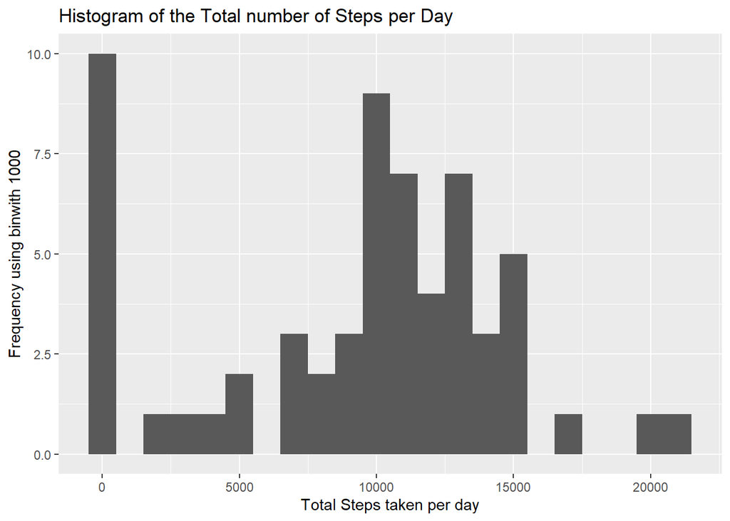

```r
Plot1<-qplot(Steps_Day,data=Steps_Day,na.rm=TRUE,binwidth=1000,
xlab= "Total Steps taken per day",
ylab="Frequency using binwith 1000",main = "Histogram of the Total number of Steps per Day")

Plot1
```

```r
dev.copy(png,'Plot1.png')
```

```r
dev.off()
```

##Objective 3: To calulate the average daily activity pattern?##

###Mean and Median number of steps taken each day.###

```r
Steps_Day_mean_median<- Steps_Day%>% summarise(average_steps = mean(Steps_Day,na.rm = TRUE),
median_steps=median(Steps_Day,na.rm = TRUE))

Steps_Day_mean_median
```

```
## # A tibble: 1 x 2
##   average_steps median_steps
##           <dbl>        <int>
## 1         9354.        10395
```

###Time series plot of the average number of steps taken.###

```r
TimeSeries_Steps<- Data_assignment %>%  group_by(interval) %>%
summarize(Steps_mean=mean(steps, na.rm=TRUE))
head(TimeSeries_Steps)
```

```
## # A tibble: 6 x 2
##   interval Steps_mean
##      <int>      <dbl>
## 1        0     1.72
## 2        5     0.340
## 3       10     0.132
## 4       15     0.151
## 5       20     0.0755
## 6       25     2.09
```

```r
tail(TimeSeries_Steps)
```

```
## # A tibble: 6 x 2
##   interval Steps_mean
##      <int>      <dbl>
## 1     2330      2.60
## 2     2335      4.70
## 3     2340      3.30
## 4     2345      0.642
## 5     2350      0.226
## 6     2355      1.08
```

```r
str(TimeSeries_Steps)
```

```
## tibble [288 x 2] (S3: tbl_df/tbl/data.frame)
##  $ interval  : int [1:288] 0 5 10 15 20 25 30 35 40 45 ...
##  $ Steps_mean: num [1:288] 1.717 0.3396 0.1321 0.1509 0.0755 ...
```

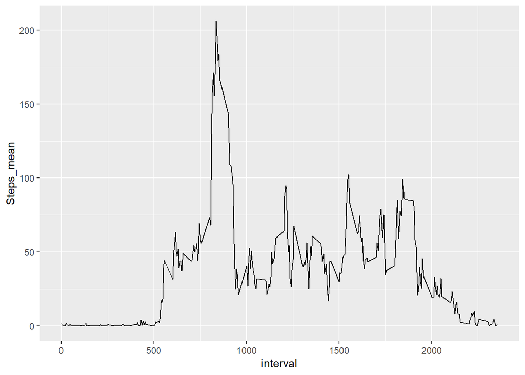

```r
Plot2<-ggplot(TimeSeries_Steps, aes(interval, Steps_mean)) + geom_line()

Plot2
```

```r
dev.copy(png, 'Plot2.png')
```

```r
dev.off()
```

###Calculate the 5-minute interval that contains the maximum number of steps?###

```r
Int_max_steps<- TimeSeries_Steps[TimeSeries_Steps$Steps_mean==max(TimeSeries_Steps$Steps_mean),]
Int_max_steps
```

```
## # A tibble: 1 x 2
##   interval Steps_mean
##      <int>      <dbl>
## 1      835       206.
```

###Calculate and report the total number of missing values in the dataset.###

```r
Data_without_NA <- na.omit(Data_assignment)
Rows_NA<- nrow(Data_assignment)-nrow(Data_without_NA)
Rows_NA
```

```
## [1] 2304
```

```r
names(TimeSeries_Steps)[2] <- "Mean_Steps"
Dataset_imputed <- merge(Data_assignment, Data_without_NA)

Dataset_imputed$steps[is.na(Dataset_imputed$steps)] <- Dataset_imputed$Mean_Steps[is.na(Dataset_imputed$Mean_Steps)]

summary(Dataset_imputed)
```

```
##      steps            date              interval         Dateform
##  Min.   :  0.00   Length:15264       Min.   :   0.0   Min.   :2012-10-02
##  1st Qu.:  0.00   Class :character   1st Qu.: 588.8   1st Qu.:2012-10-16
##  Median :  0.00   Mode  :character   Median :1177.5   Median :2012-10-29
##  Mean   : 37.38                      Mean   :1177.5   Mean   :2012-10-30
##  3rd Qu.: 12.00                      3rd Qu.:1766.2   3rd Qu.:2012-11-16
##  Max.   :806.00                      Max.   :2355.0   Max.   :2012-11-29
##
##       Day            Month          weekend          dayofweek
##  Min.   : 2.00   Min.   :10.00   weekday:11232   Friday   :2016
##  1st Qu.:10.00   1st Qu.:10.00   weekend: 4032   Monday   :2016
##  Median :17.00   Median :10.00                   Saturday :2016
##  Mean   :16.68   Mean   :10.45                   Sunday   :2016
##  3rd Qu.:24.00   3rd Qu.:11.00                   Thursday :2304
##  Max.   :31.00   Max.   :11.00                   Tuesday  :2592
##                                                  Wednesday:2304
```

```r
str(Dataset_imputed)
```

```
## 'data.frame':    15264 obs. of  8 variables:
##  $ steps    : int  0 0 0 0 0 0 0 0 0 0 ...
##  $ date     : chr  "2012-10-02" "2012-10-02" "2012-10-02" "2012-10-02" ...
##  $ interval : int  0 10 100 1000 1005 1010 1015 1020 1025 1030 ...
##  $ Dateform : Date, format: "2012-10-02" "2012-10-02" ...
##  $ Day      : int  2 2 2 2 2 2 2 2 2 2 ...
##  $ Month    : num  10 10 10 10 10 10 10 10 10 10 ...
##  $ weekend  : Factor w/ 2 levels "weekday","weekend": 1 1 1 1 1 1 1 1 1 1 ...
##  $ dayofweek: Factor w/ 7 levels "Friday","Monday",..: 6 6 6 6 6 6 6 6 6 6 ...
```

```r
head(Dataset_imputed)
```

```
##   steps       date interval   Dateform Day Month weekend dayofweek
## 1     0 2012-10-02        0 2012-10-02   2    10 weekday   Tuesday
## 2     0 2012-10-02       10 2012-10-02   2    10 weekday   Tuesday
## 3     0 2012-10-02      100 2012-10-02   2    10 weekday   Tuesday
## 4     0 2012-10-02     1000 2012-10-02   2    10 weekday   Tuesday
## 5     0 2012-10-02     1005 2012-10-02   2    10 weekday   Tuesday
## 6     0 2012-10-02     1010 2012-10-02   2    10 weekday   Tuesday
```

```r
tail(Dataset_imputed)
```

```
##       steps       date interval   Dateform Day Month weekend dayofweek
## 15259    99 2012-10-07      820 2012-10-07   7    10 weekend    Sunday
## 15260    99 2012-10-12     1330 2012-10-12  12    10 weekday    Friday
## 15261    99 2012-10-15      810 2012-10-15  15    10 weekday    Monday
## 15262    99 2012-11-06     1910 2012-11-06   6    11 weekday   Tuesday
## 15263    99 2012-11-17     1805 2012-11-17  17    11 weekend  Saturday
## 15264    99 2012-11-28     2020 2012-11-28  28    11 weekday Wednesday
```

```r
SumSteps_Day_newdata <- Dataset_imputed %>%  group_by(Dateform) %>%
summarize(Total_steps_day=sum(steps))
summary(SumSteps_Day_newdata)
```

```
##     Dateform          Total_steps_day
##  Min.   :2012-10-02   Min.   :   41
##  1st Qu.:2012-10-16   1st Qu.: 8841
##  Median :2012-10-29   Median :10765
##  Mean   :2012-10-30   Mean   :10766
##  3rd Qu.:2012-11-16   3rd Qu.:13294
##  Max.   :2012-11-29   Max.   :21194
```

```r
str(SumSteps_Day_newdata)
```

```
## tibble [53 x 2] (S3: tbl_df/tbl/data.frame)
##  $ Dateform       : Date[1:53], format: "2012-10-02" "2012-10-03" ...
##  $ Total_steps_day: int [1:53] 126 11352 12116 13294 15420 11015 12811 9900 10304 17382 ...
```

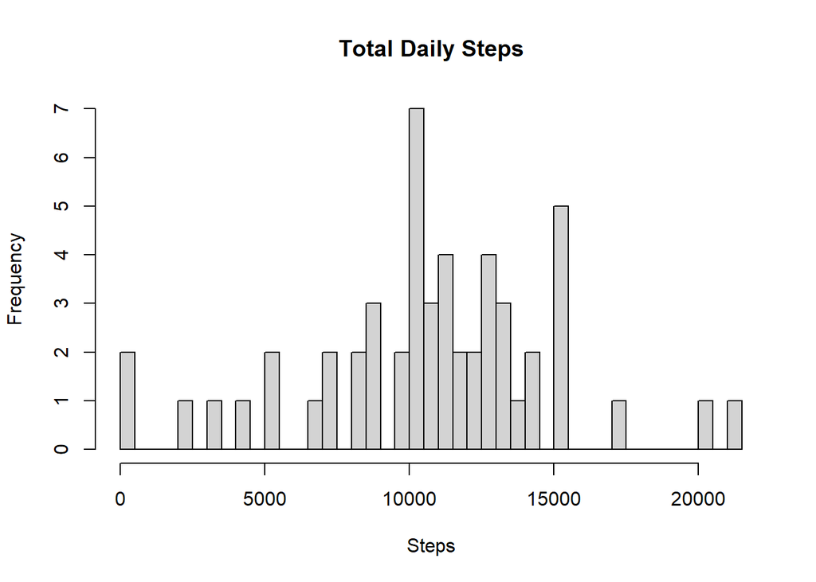

```r
Plot3<-hist(SumSteps_Day_newdata$Total_steps_day, xlab = "Steps", ylab = "Frequency", main = "Total Daily Steps", breaks=50)
```

```r
Plot3
```

[output not shown]

```r
dev.copy(png, 'Plot3.png')
```

```r
dev.off()
```

###Compare the mean and median of Old and New data.###

```r
NewData<-summary(Dataset_imputed$steps)
OldData<-summary(Data_assignment$steps, na.rm=TRUE)

NewData
```

```
##    Min. 1st Qu.  Median    Mean 3rd Qu.    Max.
##    0.00    0.00    0.00   37.38   12.00  806.00
```

```r
OldData
```

```
##    Min. 1st Qu.  Median    Mean 3rd Qu.    Max.    NA's
##    0.00    0.00    0.00   37.38   12.00  806.00    2304
```

```r
str(Dataset_imputed)
```

```
## 'data.frame':    15264 obs. of  8 variables:
##  $ steps    : int  0 0 0 0 0 0 0 0 0 0 ...
##  $ date     : chr  "2012-10-02" "2012-10-02" "2012-10-02" "2012-10-02" ...
##  $ interval : int  0 10 100 1000 1005 1010 1015 1020 1025 1030 ...
##  $ Dateform : Date, format: "2012-10-02" "2012-10-02" ...
##  $ Day      : int  2 2 2 2 2 2 2 2 2 2 ...
##  $ Month    : num  10 10 10 10 10 10 10 10 10 10 ...
##  $ weekend  : Factor w/ 2 levels "weekday","weekend": 1 1 1 1 1 1 1 1 1 1 ...
##  $ dayofweek: Factor w/ 7 levels "Friday","Monday",..: 6 6 6 6 6 6 6 6 6 6 ...
```

###Create a time series plot of the 5-minute interval (x-axis) and the average number of steps taken, averaged across all weekday days or weekend days (y-axis).###

```r
Average_Steps<- Dataset_imputed %>% group_by(interval,weekend) %>%
  summarise(Average_Steps = mean(steps))
summary(Average_Steps)
```

```
##     interval         weekend    Average_Steps
##  Min.   :   0.0   weekday:288   Min.   :  0.000
##  1st Qu.: 588.8   weekend:288   1st Qu.:  1.854
##  Median :1177.5                 Median : 26.295
##  Mean   :1177.5                 Mean   : 39.208
##  3rd Qu.:1766.2                 3rd Qu.: 62.321
##  Max.   :2355.0                 Max.   :234.103
```

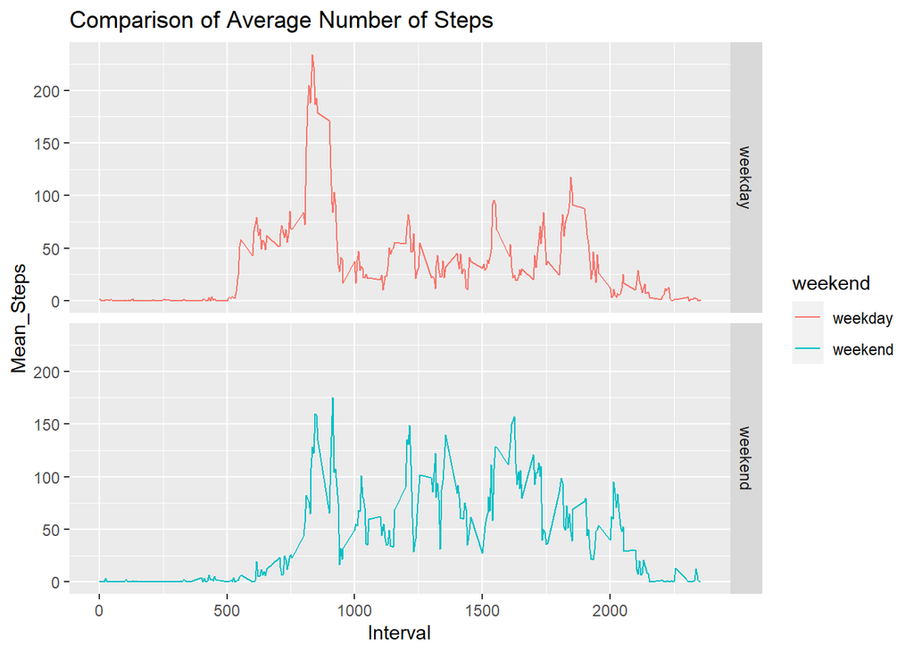

```r
Plot4<-ggplot(Average_Steps, aes(x=interval, y=Average_Steps, color=weekend)) + geom_line(linetype=1)+ facet_grid(weekend~.)+ xlab("Interval") + ylab("Mean_Steps") +
ggtitle("Comparison of Average Number of Steps")

Plot4
```

```r
dev.copy(png, "Plot4.png")
```

```r
dev.off()
```

===========================================================================================